# Stat 414 Lab 1

Eric Ortiz, Nick Browen

Large scale alteration (e.g., destruction) of native prairie communities has been associated with numerous problems (e.g., soil erosion, lack of biodiversity of plants, increase in atmospheric CO2). This has led to an increase in prairie reconstruction projects, but there has been a lot of variability in the success of these projects, even those using the same seed combinations and dispersal techniques in different years.

A 3x2x2 factorial design was conducted to investigate the impact of soil type (remnant, cultivated, restored), sterilization (yes or no), and species (leadplant and cornflower) on the height on germinating plants. Each of the 12 treatments was replicated in 6 pots, for a total of 72 pots. Six seeds were planted in each pot. (OK, a few pots had more than six plants, probably because two of the microscopically small seeds stuck together when planted.) Measurements on each plant in each pot were taken at 13, 18, 23, and 28 days after planting. Plants that did not germinate are removed from the analysis (so we will restrict our study conclusions to plants that germinate!). Not all plants survived to the end of the 28th day.

### Part 0

**Remove the 154 plants that did not germinate by Day 28, but keep plants that had some growth but did not survive for the whole study. Make sure the remaining missing values are coded in a way R/JMP can understand.**

### Part A

**Identify the three-levels in this data set.**

Level 1: plant measurements (height after some number of days)

Level 2: plant

Level 3: pot

### Part B

**Calculate the mean height for each plant for the existing measurements for that plant. (Document how you do so.) Examine boxplots of these plant heights across the soil type, separately for the coneflowers and the leadplants. Examine boxplots of the plant heights across sterilization, separately for the coneflowers and the leadplants. Summarize what you learn, including any differences in associations between species.**

```r
plant.data$hgtMean = rowMeans(plant.data %>% select(hgt13, hgt18, hgt23, hgt28), na.rm = T)
```

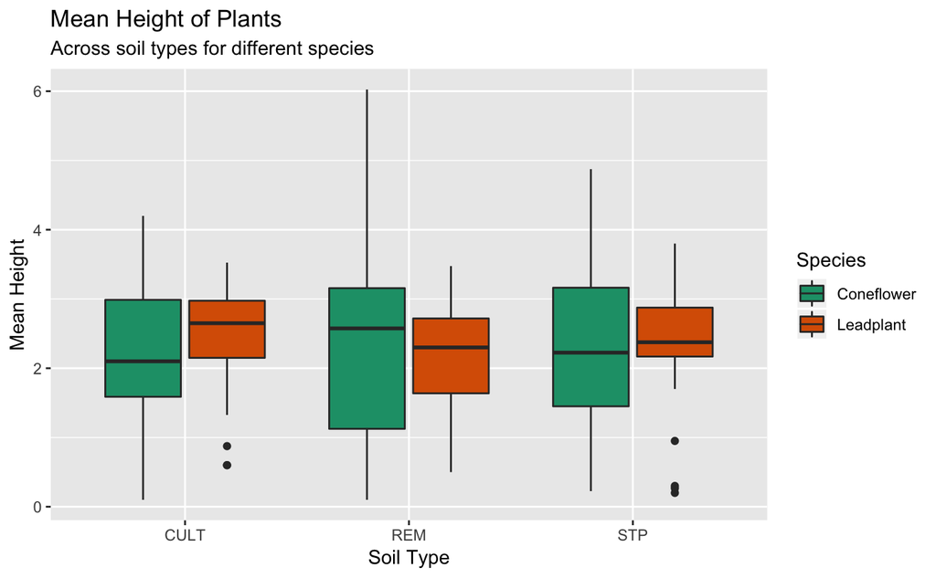

From this plot, we can see that the mean height of plants of species Coneflower is slightly higher for remnant soil than for cultivated and restored soils. However, the means are all similar and I suspect that there is not a significant difference betwen the three.

We can also see that for plants of species Leadplant, the mean height of plants grown in cultivated soil is slightly higher than for plants grown in remnant and restored soils.

When comparing the two species, Leadplants tend to do better in cultivated soil, Coneflowers tend to do better in remnant soil, and there doesn’t seem to be a large difference for restored soil.

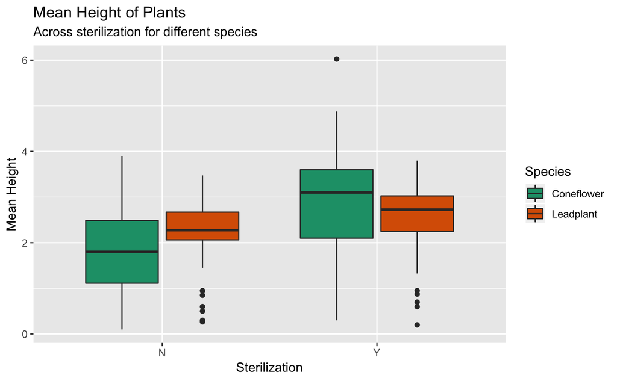

From this plot, we can see that both Leadplants and Coneflowers have a larger mean height when sterilized, but this difference is larger for Coneflowers.

**Convert the data to long format (document how you do so)**

```r
plant.long <- gather(plant.data, day, height, hgt13:hgt28, factor_key = T)
```

### Part C

**Examine spaghetti plots of the plant heights across the measurements for each of the species. Is it reasonable to assume linear growth between Day 13 and Day 28? Does the initial height and/or rate of growth seem to differ between the species? Is there more variability in one species than the other?**

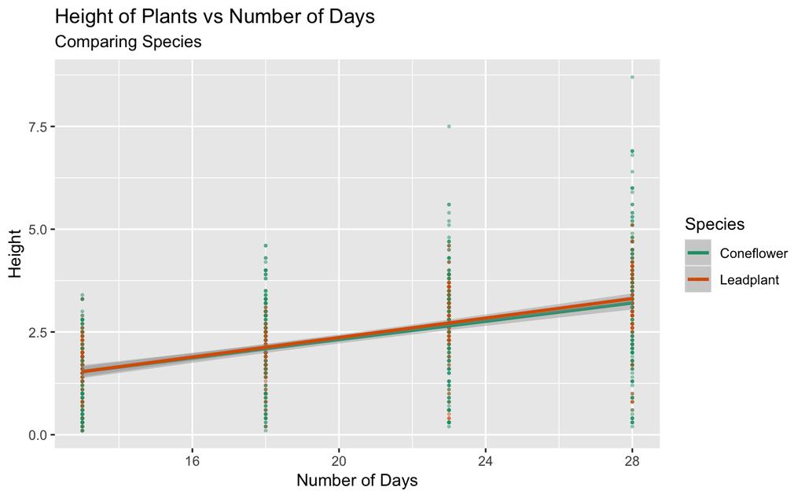

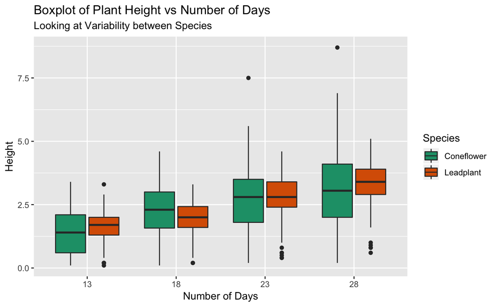

Looking at the scatter plot, I think it is reasonable to assume linear growth of plants over time. Of course, this isn’t perfectly linear nor can a plant grow linearly for an infinite amount of time. But for our 28 day experiment we can assume the growth is linear. The growth rate does not seem to differ much between species (slope) nor does the initial height seem do differ between species (intercept).

Looking at variability in the boxplot, we can see that there is more variability in the growth rates of Cornflowers than in Leadplants as seen in the whiskers of the plot for each time point where measurements were taken.

### Part D

**Examine spaghetti plots of the plant heights over time separately for the three types of soil, separately for each species. What do you learn?**

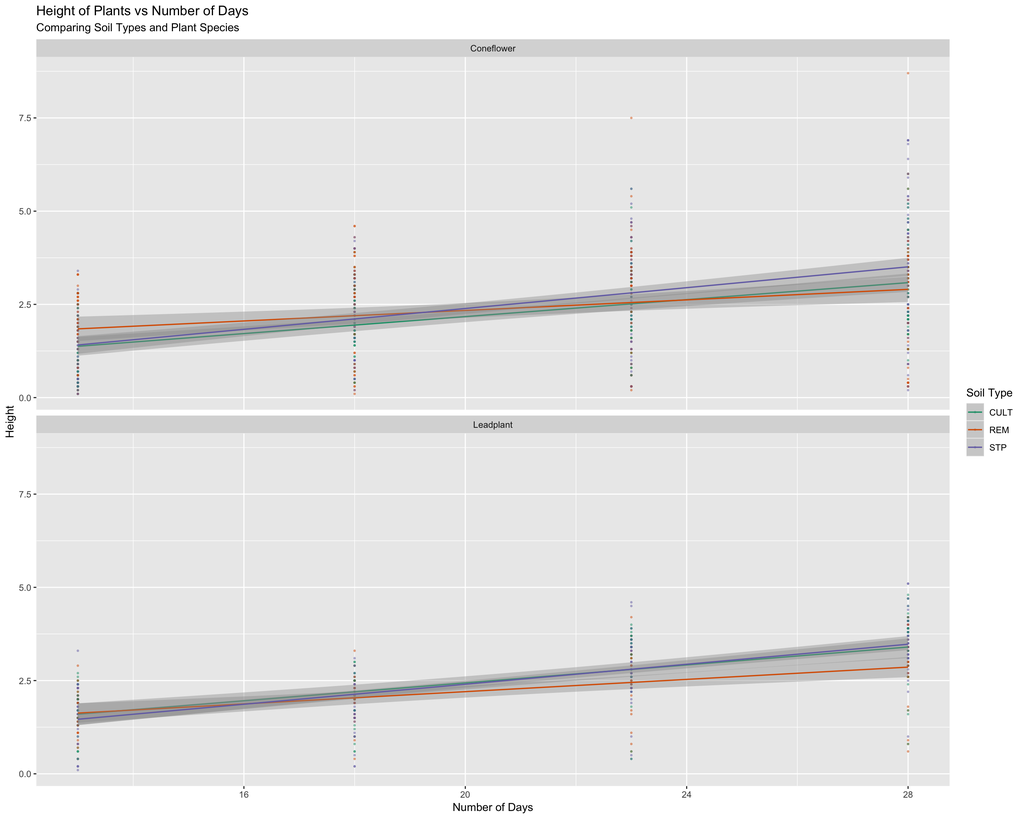

We can see that for both species, there is a noticeably different rate of growth for plants grown in restored soil compared to remnant soil. However, when looking at plants grown in cultivated soil, Cornflowers and leadplants differ; Cornflowers have a lower rate of growth in soil than Leadplants.

**Split the data into two datasets, one with leadplants and one with coneflowers.**

```r
lead <- plant.long %>% filter(species == "Leadplant")
cone <- plant.long %>% filter(species == "Coneflower")
lead
```

| id | pot | plant | soil | sterile | species | germin | hgtMean | day | height | dayNum |
| --- | --- | --- | --- | --- | --- | --- | --- | --- | --- | --- |
| 1 | 1 | 11 | STP | Y | Leadplant | Y | 3.7000000 | hgt13 | 2.3 | 13 |
| 2 | 1 | 12 | STP | Y | Leadplant | Y | 2.5000000 | hgt13 | 1.9 | 13 |
| 3 | 1 | 13 | STP | Y | Leadplant | Y | 2.5000000 | hgt13 | 1.5 | 13 |
| 4 | 1 | 14 | STP | Y | Leadplant | Y | 2.3500000 | hgt13 | 1.5 | 13 |
| 5 | 1 | 15 | STP | Y | Leadplant | Y | 3.1250000 | hgt13 | 2.4 | 13 |
| 6 | 1 | 16 | STP | Y | Leadplant | Y | 2.2250000 | hgt13 | 1.3 | 13 |
| 7 | 2 | 21 | REM | Y | Leadplant | Y | 2.3000000 | hgt13 | 1.7 | 13 |
| 13 | 3 | 31 | REM | N | Leadplant | Y | 0.5000000 | hgt13 | 0.4 | 13 |
| 19 | 4 | 41 | REM | Y | Leadplant | Y | 0.9500000 | hgt13 | 0.8 | 13 |
| 39 | 7 | 71 | CULT | Y | Leadplant | Y | 3.4750000 | hgt13 | 2.5 | 13 |

[output cut: 418 more lines]

## Focusing on just the leadplants

### Part F

**“Center” the time variable by subtracting 13. Fit an “unconditional means” or random intercepts null model with no predictors but the three-level hierarchy. How many parameters are estimated? Provide an interpretation of each, including the variance components.**

```r
lead <- lead %>% mutate(
  dayNum_centered = dayNum - 13
)
```

```r
mod.f <- lmer(data = lead, formula = height ~ 1 + (1 | pot / plant))
summary(mod.f)
```

```
Linear mixed model fit by REML ['lmerMod']
Formula: height ~ 1 + (1 | pot/plant)
   Data: lead

REML criterion at convergence: 1148.8

Scaled residuals:
    Min      1Q  Median      3Q     Max
-2.2210 -0.7022 -0.2129  0.7259  2.2810

Random effects:
 Groups    Name        Variance Std.Dev.
 plant:pot (Intercept) 0.27817  0.5274
 pot       (Intercept) 0.04873  0.2207
 Residual              0.72782  0.8531
Number of obs: 413, groups:  plant:pot, 107; pot, 32

Fixed effects:
            Estimate Std. Error t value
(Intercept)  2.38808    0.07887   30.28
```

There are 4 parameters estimated.  
1. Grand Mean: The average height of Leadplants in the average pot for the average plant is 2.38808.  
2. Residual: The within-plant variance of measurements is 0.72782.  
3. Pot: The between-pot variance is 0.04873.  
4. Plant:Pot: The beteen-plant (within same pot) variance is 0.27817.

### Part G

**Include the centered time variable in the model, assuming linear growth, with random intercepts and slopes (at both levels). How much of the within-plant variability is explained by the linear changes over time? Interpret the fixed effects. Are either of the fixed effects statistically significant? How many variance/covariance parameters are there?**

```r
mod.g <- lmer(data = lead, formula = height ~ dayNum_centered + (dayNum_centered | pot / plant))
summary(mod.g)
```

```
Linear mixed model fit by REML ['lmerMod']
Formula: height ~ dayNum_centered + (dayNum_centered | pot/plant)
   Data: lead

REML criterion at convergence: 597.2

Scaled residuals:
     Min       1Q   Median       3Q      Max
-2.67636 -0.52647  0.01895  0.54522  2.81911

Random effects:
 Groups    Name            Variance Std.Dev. Corr
 plant:pot (Intercept)     0.299163 0.54696
           dayNum_centered 0.001194 0.03456  0.28
 pot       (Intercept)     0.044219 0.21028
           dayNum_centered 0.001261 0.03551  -0.61
 Residual                  0.082157 0.28663
Number of obs: 413, groups:  plant:pot, 107; pot, 32

Fixed effects:
                Estimate Std. Error t value
(Intercept)     1.537696   0.070304   21.87
dayNum_centered 0.112117   0.007924   14.15

Correlation of Fixed Effects:
            (Intr)
dayNm_cntrd -0.277
```

The within-plant variance is 0.0822 in this model. We can compute a pseudo-$R^2$ using the variance components of this model and the model in part f. Including the linear changes over time decreased the within-plant variability by 88.7%.

$\text{pseudo} \ R^2 = \frac{0.72782 - 0.0822}{0.72782} = 0.887$

1. Intercept: The average height of Leadplants at day 13 in the average pot for the average plant is 1.5376.
2. dayNum_centered: For the average plant in the average pot, each increase of one day (after day 13) is associated with a 0.112 unit increase in the average height of a plant.

Yes, the intercept (t-value = 21.87) and slope for dayNum_centered (t-value = 14.15) are highly statistically significant.

### Part H

**Now add the sterilization and soil type variables. You will want to include interactions with the time variable. Is this model a significant improvement from the model in part G?**

```r
mod.h <- lmer(data = lead, formula = height ~ dayNum_centered + sterile + soil + sterile*dayNum_centered + soil*dayNum_centered + (dayNum_centered | pot / plant))
summary(mod.h)
```

```
Linear mixed model fit by REML ['lmerMod']
Formula: height ~ dayNum_centered + sterile + soil + sterile * dayNum_centered +
    soil * dayNum_centered + (dayNum_centered | pot/plant)
   Data: lead

REML criterion at convergence: 593.2

Scaled residuals:
     Min       1Q   Median       3Q      Max
-2.68828 -0.52497  0.02211  0.53654  2.94318

Random effects:
 Groups    Name            Variance  Std.Dev. Corr
 plant:pot (Intercept)     0.2980210 0.54591
           dayNum_centered 0.0012081 0.03476  0.28
 pot       (Intercept)     0.0531507 0.23054
           dayNum_centered 0.0001317 0.01148  -1.00
 Residual                  0.0820768 0.28649
Number of obs: 413, groups:  plant:pot, 107; pot, 32

Fixed effects:
                          Estimate Std. Error t value
(Intercept)               1.632906   0.182596   8.943
dayNum_centered           0.071304   0.012556   5.679
sterileY                 -0.076546   0.151368  -0.506
soilREM                   0.008374   0.209795   0.040
soilSTP                  -0.130013   0.182723  -0.712
dayNum_centered:sterileY  0.058917   0.010282   5.730
dayNum_centered:soilREM  -0.006095   0.014647  -0.416
dayNum_centered:soilSTP   0.029765   0.012263   2.427

Correlation of Fixed Effects:
            (Intr) dyNm_c sterlY solREM solSTP dyN_:Y dN_:RE
dayNm_cntrd -0.230
sterileY    -0.613  0.149
soilREM     -0.715  0.153  0.279
soilSTP     -0.758  0.168  0.219  0.605
dyNm_cntr:Y  0.151 -0.632 -0.254 -0.051 -0.046
dyNm_cn:REM  0.152 -0.734 -0.052 -0.207 -0.129  0.347
dyNm_cn:STP  0.173 -0.777 -0.047 -0.134 -0.252  0.257  0.616
```

```r
anova(mod.g, mod.h)
```

```
refitting model(s) with ML (instead of REML)
```

```
Data: lead
Models:
mod.g: height ~ dayNum_centered + (dayNum_centered | pot/plant)
mod.h: height ~ dayNum_centered + sterile + soil + sterile * dayNum_centered +
mod.h:     soil * dayNum_centered + (dayNum_centered | pot/plant)
      Df    AIC    BIC  logLik deviance  Chisq Chi Df Pr(>Chisq)
mod.g  9 603.76 639.97 -292.88   585.76
mod.h 15 583.55 643.90 -276.78   553.55 32.202      6  1.493e-05 ***
---
Signif. codes:  0 ‘***’ 0.001 ‘**’ 0.01 ‘*’ 0.05 ‘.’ 0.1 ‘ ’ 1
```

Using a Chi-Square test between the two models, we can conclude that the model including `sterile` and `soil` is a significant improvement over the model that doesn’t ($\chi^2 = 32.202$ and p-value = 0.000015).

### Part I

**You are probably running into some boundary conditions with this model. One option is to simplify the model, e.g., removing some variance components. Modify the previous model so that the Level 3 intercepts are random but the Level 3 slopes are fixed. What is the practical interpretation of this modelling choice? Does this change the estimates of the fixed effects? How many parameters have you removed from the model? [This model should be more stable, and if you check shouldn’t be significantly worse.]**

```r
mod.i <- lmer(data = lead, formula = height ~ dayNum_centered + sterile + soil + (dayNum_centered | pot / plant))
summary(mod.i)
```

```
Linear mixed model fit by REML ['lmerMod']
Formula: height ~ dayNum_centered + sterile + soil + (dayNum_centered |      pot/plant)
   Data: lead

REML criterion at convergence: 602.2

Scaled residuals:
     Min       1Q   Median       3Q      Max
-2.65542 -0.52624  0.02195  0.55301  2.77899

Random effects:
 Groups    Name            Variance Std.Dev. Corr
 plant:pot (Intercept)     0.303412 0.55083
           dayNum_centered 0.001217 0.03489  0.28
 pot       (Intercept)     0.068463 0.26166
           dayNum_centered 0.001207 0.03474  -0.81
 Residual                  0.082141 0.28660
Number of obs: 413, groups:  plant:pot, 107; pot, 32

Fixed effects:
                 Estimate Std. Error t value
(Intercept)      1.473099   0.179270   8.217
dayNum_centered  0.112783   0.007812  14.438
sterileY         0.162397   0.144890   1.121
soilREM         -0.033445   0.204365  -0.164
soilSTP         -0.012187   0.174753  -0.070

Correlation of Fixed Effects:
            (Intr) dyNm_c sterlY solREM
dayNm_cntrd -0.182
sterileY    -0.607  0.021
soilREM     -0.712  0.022  0.297
soilSTP     -0.753 -0.023  0.229  0.610
```

We are acknowledging that the “effect” of sterile and soil can differ by pot on day 13, but that the increase in heights day by day associated with soil and sterile are the same for all pots.

Yes, several fixed effect estimates changed. Notably, sterileY went from negative in the old model to positive in this model, soilREM changed sign from positive to negative.

We removed 3 parameters from the model.

### Part J

**Now add the Level 3 interaction between sterilization and soil types (including the interaction with time!). Compare this to the model that does not allow sterilization or soil type (or their interaction) to influence Day 13 measurements. Why do I make this suggestion? Is there a significant difference between these two models?**

```r
mod.j <- lmer(data = lead, formula = height ~ dayNum_centered + sterile + soil + sterile*soil*dayNum_centered + (dayNum_centered | pot / plant))
summary(mod.j)
```

```
Linear mixed model fit by REML ['lmerMod']
Formula: height ~ dayNum_centered + sterile + soil + sterile * soil *      dayNum_centered + (dayNum_centered | pot/plant)
   Data: lead

REML criterion at convergence: 599.2

Scaled residuals:
    Min      1Q  Median      3Q     Max
-2.6694 -0.5249  0.0336  0.5511  2.8881

Random effects:
 Groups    Name            Variance  Std.Dev. Corr
 plant:pot (Intercept)     0.2979036 0.54581
           dayNum_centered 0.0011667 0.03416  0.28
 pot       (Intercept)     0.0618610 0.24872
           dayNum_centered 0.0001249 0.01117  -1.00
 Residual                  0.0820108 0.28638
Number of obs: 413, groups:  plant:pot, 107; pot, 32

Fixed effects:
                                   Estimate Std. Error t value
(Intercept)                       1.4782730  0.2882338   5.129
dayNum_centered                   0.0748432  0.0201437   3.715
sterileY                          0.1316250  0.3357981   0.392
soilREM                           0.1883426  0.3394154   0.555
soilSTP                           0.0547409  0.3247016   0.169
sterileY:soilREM                 -0.3235801  0.4508347  -0.718
sterileY:soilSTP                 -0.2675170  0.3995713  -0.670
dayNum_centered:sterileY          0.0541585  0.0229105   2.364
dayNum_centered:soilREM           0.0003524  0.0230659   0.015
dayNum_centered:soilSTP           0.0189059  0.0221147   0.855
dayNum_centered:sterileY:soilREM -0.0335222  0.0314217  -1.067
dayNum_centered:sterileY:soilSTP  0.0205189  0.0265231   0.774

Correlation of Fixed Effects:
            (Intr) dyNm_c sterlY solREM solSTP sY:REM sY:STP dyN_:Y dN_:RE dN_:ST dN_:Y:R
dayNm_cntrd -0.202
sterileY    -0.858  0.173
soilREM     -0.849  0.171  0.729
soilSTP     -0.888  0.179  0.762  0.754
strlY:slREM  0.639 -0.129 -0.745 -0.753 -0.568
strlY:slSTP  0.721 -0.146 -0.840 -0.613 -0.813  0.626
dyNm_cntr:Y  0.177 -0.879 -0.215 -0.151 -0.157  0.160  0.181
dyNm_cn:REM  0.176 -0.873 -0.151 -0.218 -0.156  0.164  0.127  0.768
dyNm_cn:STP  0.184 -0.911 -0.158 -0.156 -0.228  0.117  0.185  0.801  0.795
dyNm_:Y:REM -0.129  0.641  0.157  0.160  0.115 -0.192 -0.132 -0.729 -0.734 -0.584
dyNm_:Y:STP -0.153  0.759  0.186  0.130  0.190 -0.138 -0.244 -0.864 -0.663 -0.834  0.630
```

```r
anova(mod.i, mod.j)
```

```
refitting model(s) with ML (instead of REML)
```

```
Data: lead
Models:
mod.i: height ~ dayNum_centered + sterile + soil + (dayNum_centered |
mod.i:     pot/plant)
mod.j: height ~ dayNum_centered + sterile + soil + sterile * soil *
mod.j:     dayNum_centered + (dayNum_centered | pot/plant)
      Df    AIC    BIC  logLik deviance  Chisq Chi Df Pr(>Chisq)
mod.i 12 608.84 657.13 -292.42   584.84
mod.j 19 585.86 662.31 -273.93   547.86 36.982      7  4.727e-06 ***
---
Signif. codes:  0 ‘***’ 0.001 ‘**’ 0.01 ‘*’ 0.05 ‘.’ 0.1 ‘ ’ 1
```

We think you might have suggested this because you think that the effect of sterilzation on Day 13 heights is dependent on soil type and this changes over time.

### Part K

**This is your final model. Interpret it! (A brief summary of the important features, especially as the agree/disagree with your exploratory data analysis. What seems to maximize growth!)**

To maximize growth, we would want to maximize the slope of height’s association with time. Looking at the coefficients for the fixed effects we can see that with regards to height, soilSTP has a positive “effect” on growth per day of 0.019, sterile plants have a positive “effect” on growth per day of 0.054, and the interaction with soilSTP and sterile plants have a positive “effect” on growth per day of 0.021. The combination of STP soil and sterile plants maximizes the growth per day to 0.169 units/day.

This seems to agree with our EDA as the plot in part D shows the soil type STP having the largest growth rate for Leadplants and the plot in part B shows sterile plants having a larger height than non-sterile plants.

### Part L

**Reconsider adding the Level 3 interaction in part J, but for the model in part I that still had random slopes at Level 3. Run this model; how many parameters are in this model?**

```r
mod.l <- lmer(data = lead, formula = height ~ dayNum_centered + sterile + soil + sterile*soil  + (dayNum_centered | pot / plant))
summary(mod.l)
```

```
Linear mixed model fit by REML ['lmerMod']
Formula: height ~ dayNum_centered + sterile + soil + sterile * soil +      (dayNum_centered | pot/plant)
   Data: lead

REML criterion at convergence: 601.6

Scaled residuals:
     Min       1Q   Median       3Q      Max
-2.64842 -0.51631  0.01825  0.54803  2.74949

Random effects:
 Groups    Name            Variance Std.Dev. Corr
 plant:pot (Intercept)     0.305686 0.55289
           dayNum_centered 0.001234 0.03513  0.28
 pot       (Intercept)     0.091458 0.30242
           dayNum_centered 0.001173 0.03425  -0.93
 Residual                  0.082123 0.28657
Number of obs: 413, groups:  plant:pot, 107; pot, 32

Fixed effects:
                  Estimate Std. Error t value
(Intercept)       1.323030   0.282081   4.690
dayNum_centered   0.112698   0.007744  14.552
sterileY          0.371066   0.323474   1.147
soilREM           0.147033   0.326109   0.451
soilSTP           0.083624   0.310280   0.270
sterileY:soilREM -0.405372   0.438910  -0.924
sterileY:soilSTP -0.045663   0.377583  -0.121

Correlation of Fixed Effects:
            (Intr) dyNm_c sterlY solREM solSTP sY:REM
dayNm_cntrd -0.121
sterileY    -0.856 -0.023
soilREM     -0.849 -0.024  0.744
soilSTP     -0.891 -0.043  0.782  0.776
strlY:slREM  0.626  0.058 -0.738 -0.744 -0.578
strlY:slSTP  0.733  0.025 -0.857 -0.637 -0.821  0.633
```

There are 14 parameters being estimated.

## Repeat for coneflowers

11. Repeat the initial model in (j) for the coneflowers. Does the model also suggest that sterilization and soil type (or their interaction) don’t impact Day 13 measurements for this species? What other differences do you see in comparing the models for leadplants and coneflowers?

### Center the dayNum variable for Coneflowers

```r
cone <- cone %>% mutate(
  dayNum_centered = dayNum - 13
)
```

```r
coneMod.j <- lmer(data = cone, formula = height ~ dayNum_centered + sterile + soil + sterile*soil*dayNum_centered + (dayNum_centered | pot / plant))
summary(coneMod.j)
```

```
Linear mixed model fit by REML ['lmerMod']
Formula: height ~ dayNum_centered + sterile + soil + sterile * soil *      dayNum_centered + (dayNum_centered | pot/plant)
   Data: cone

REML criterion at convergence: 1286

Scaled residuals:
    Min      1Q  Median      3Q     Max
-3.2127 -0.4965  0.0136  0.4910  2.7489

Random effects:
 Groups    Name            Variance  Std.Dev. Corr
 plant:pot (Intercept)     0.3935672 0.62735
           dayNum_centered 0.0025227 0.05023  0.49
 pot       (Intercept)     0.0893146 0.29886
           dayNum_centered 0.0003708 0.01926  0.09
 Residual                  0.1459447 0.38203
Number of obs: 650, groups:  plant:pot, 176; pot, 35

Fixed effects:
                                  Estimate Std. Error t value
(Intercept)                       0.982665   0.189697   5.180
dayNum_centered                   0.079594   0.014889   5.346
sterileY                          0.712695   0.282249   2.525
soilREM                           1.102962   0.255432   4.318
soilSTP                          -0.052076   0.254064  -0.205
sterileY:soilREM                 -1.604088   0.391493  -4.097
sterileY:soilSTP                  0.160884   0.369979   0.435
dayNum_centered:sterileY          0.075318   0.021898   3.439
dayNum_centered:soilREM          -0.021576   0.020146  -1.071
dayNum_centered:soilSTP          -0.001028   0.020207  -0.051
dayNum_centered:sterileY:soilREM -0.034254   0.030630  -1.118
dayNum_centered:sterileY:soilSTP  0.033339   0.028818   1.157

Correlation of Fixed Effects:
            (Intr) dyNm_c sterlY solREM solSTP sY:REM sY:STP dyN_:Y dN_:RE dN_:ST dN_:Y:R
dayNm_cntrd  0.117
sterileY    -0.672 -0.079
soilREM     -0.743 -0.087  0.499
soilSTP     -0.747 -0.087  0.502  0.555
strlY:slREM  0.485  0.057 -0.721 -0.652 -0.362
strlY:slSTP  0.513  0.060 -0.763 -0.381 -0.687  0.550
dyNm_cntr:Y -0.080 -0.680  0.114  0.059  0.059 -0.082 -0.087
dyNm_cn:REM -0.087 -0.739  0.058  0.114  0.065 -0.075 -0.044  0.502
dyNm_cn:STP -0.086 -0.737  0.058  0.064  0.102 -0.042 -0.070  0.501  0.545
dyNm_:Y:REM  0.057  0.486 -0.081 -0.075 -0.043  0.109  0.062 -0.715 -0.658 -0.358
dyNm_:Y:STP  0.061  0.517 -0.086 -0.045 -0.071  0.062  0.110 -0.760 -0.382 -0.701  0.543
```

Looking at the fixed effects, sterileY (t-value = 2.525), soilREM (t-value = 4.318), sterileY*soilREM (t-value = -4.097) all statistically significantly impact Day 13 height measurements.

The within plant measurement variance for Coneflowers ($\sigma^2 = 0.146$) is much bigger than the within plant measurement variance for Leadplants ($\sigma^2 = 0.082$). This also lines up with our EDA plots because the Coneflowers had more visible variablility than the Leadplants.